# Análisis Exploratorio de los Datos: MORTALIDAD TRATABLE Y PREVENIBLE , MORTALIDAD POR ENFERMEDADES INFECCIOSAS

Alicia Perdices Guerra

21 de mayo, 2021

- **1.ANÁLISIS EXPLORATORIO POR PAISES.**
  - 1.1 EN RELACIÓN CON LA MORTALIDAD
    - 1.1.1 Análisis Descriptivo
    - 1.1.2 Visualización y Distribución de la variable “Value (Mortalidad)”
      - MORTALIDAD TRATABLE Y PREVENIBLE.
      - MORTALIDAD POR ENFERMEDADES INFECCIOSAS.
    - 1.1.3 Normalidad de la variable “Value (Mortalidad)”
      - MORTALIDAD TRATABLE Y PREVENIBLE.
      - MORTALIDAD POR ENFERMEDADES INFECCIOSAS.

#### **1.ANÁLISIS EXPLORATORIO POR PAISES**

Se procede en primer lugar a cargar todos los archivos para poder realizar el análisis.

```r
mortalidad_tp<-read.csv("C:/temp/Mortalidad_Tratable_Prevenible_clean.csv",sep= ",")
mortalidad_ei<-read.csv("C:/temp/Muertes_Enf_Infecciosas_clean.csv",sep= ",")
```

**1.1.- EN RELACIÓN CON LA MORTALIDAD**

- **1.1.1 Análisis Descriptivo**

Se procede a realizar el análisis descriptivo:

```r
summary(mortalidad_tp)
```

```
##       TIME          GEO              MORTALIT             SEX
##  Min.   :2011   Length:4536        Length:4536        Length:4536
##  1st Qu.:2012   Class :character   Class :character   Class :character
##  Median :2014   Mode  :character   Mode  :character   Mode  :character
##  Mean   :2014
##  3rd Qu.:2016
##  Max.   :2017
##     ICD10               UNIT               Value           Value_imp
##  Length:4536        Length:4536        Min.   :      6.5   Mode :logical
##  Class :character   Class :character   1st Qu.:    154.3   FALSE:4482
##  Mode  :character   Mode  :character   Median :    373.9   TRUE :54
##                                        Mean   :  22272.2
##                                        3rd Qu.:   8195.9
##                                        Max.   :1210890.0
```

```r
summary(mortalidad_ei)
```

```
##       TIME          GEO                UNIT               SEX
##  Min.   :2011   Length:1332        Length:1332        Length:1332
##  1st Qu.:2013   Class :character   Class :character   Class :character
##  Median :2015   Mode  :character   Mode  :character   Mode  :character
##  Mean   :2015
##  3rd Qu.:2017
##  Max.   :2019
##     ICD10               Value        Value_imp
##  Length:1332        Min.   :     0   Mode :logical
##  Class :character   1st Qu.:   223   FALSE:1176
##  Mode  :character   Median :  1074   TRUE :156
##                     Mean   :  6755
##                     3rd Qu.:  4156
##                     Max.   :133225
```

Se filta el dataframe para que la variable GEO aparezcan solo los paises objeto de estudio.(Para cada archivo relacionado con La Mortalidad y unificamos la información ). Además se selecciona la información relevante de las variables MORTALIT (tipo de Mortalidad), SEX (Total), UNIT(Number) e ICD10 (tipo de enfermedad infecciosa)

```r
#En relación con la MORTALIDAD TRATABLE/PREVENIBLE
#=================================================


mortalidad_tp_paises<-filter(mortalidad_tp,
             +(GEO!="European Union - 27 countries (from 2020)")&
             +(GEO!="European Union - 28 countries (2013-2020)"))

#Mortalidad prevenible
mortalidad_pre<-filter(mortalidad_tp_paises,MORTALIT=="Preventable mortality",SEX=="Total",UNIT=="Number")
head(mortalidad_pre)
```

```
##   TIME                                              GEO              MORTALIT
## 1 2011                                          Belgium Preventable mortality
## 2 2011                                         Bulgaria Preventable mortality
## 3 2011                                          Czechia Preventable mortality
## 4 2011                                          Denmark Preventable mortality
## 5 2011 Germany (until 1990 former territory of the FRG) Preventable mortality
## 6 2011                                          Estonia Preventable mortality
##     SEX ICD10   UNIT    Value Value_imp
## 1 Total Total Number  15883.5     FALSE
## 2 Total Total Number  15459.5     FALSE
## 3 Total Total Number  20972.5     FALSE
## 4 Total Total Number   9022.0     FALSE
## 5 Total Total Number 127461.0     FALSE
## 6 Total Total Number   3555.0     FALSE
```

```r
nrow(mortalidad_pre)
```

```
## [1] 238
```

```r
#Mortalidad tratable
mortalidad_tra<-filter(mortalidad_tp_paises,MORTALIT=="Treatable mortality",SEX=="Total",UNIT=="Number")
head(mortalidad_tra)
```

```
##   TIME                                              GEO            MORTALIT
## 1 2011                                          Belgium Treatable mortality
## 2 2011                                         Bulgaria Treatable mortality
## 3 2011                                          Czechia Treatable mortality
## 4 2011                                          Denmark Treatable mortality
## 5 2011 Germany (until 1990 former territory of the FRG) Treatable mortality
## 6 2011                                          Estonia Treatable mortality
##     SEX ICD10   UNIT   Value Value_imp
## 1 Total Total Number  7459.5     FALSE
## 2 Total Total Number 13422.5     FALSE
## 3 Total Total Number 13383.5     FALSE
## 4 Total Total Number  4445.0     FALSE
## 5 Total Total Number 74029.0     FALSE
## 6 Total Total Number  1870.0     FALSE
```

```r
nrow(mortalidad_tra)
```

```
## [1] 238
```

```r
#En relación con la MORTALIDAD POR ENFERMEDADES INFECCIOSAS
#==========================================================

mortalidad_ei_paises<-filter(mortalidad_ei,
             +(GEO!="European Union - 27 countries (from 2020)")&
             +(GEO!="European Union - 28 countries (2013-2020)")&
             +(GEO!="France (metropolitan)"))
#Filtramos TIME (2011-2017), para poder hacer comparar con la información de mortalidad prevenible y trabable en ese periodo de tiempo.
mortalidad_ei_paises<-filter(mortalidad_ei_paises,
             +(TIME!=2018)&
             +(TIME!=2019))
#Mortalidad por enfermedades infecciosas clasificadas por ICD-10-CM Codes:https://www.icd10data.com/ICD10CM/Codes

# Certain infectious and parasitic diseases A00-B99
mortalidad_A00_B99<-filter(mortalidad_ei_paises, ICD10=="Certain infectious diseases (A00-A40, A42-B99)")
head(mortalidad_A00_B99)
```

```
##   TIME                                              GEO   UNIT   SEX
## 1 2011                                          Belgium Number Total
## 2 2011                                         Bulgaria Number Total
## 3 2011                                          Czechia Number Total
## 4 2011                                          Denmark Number Total
## 5 2011 Germany (until 1990 former territory of the FRG) Number Total
## 6 2011                                          Estonia Number Total
##                                            ICD10 Value Value_imp
## 1 Certain infectious diseases (A00-A40, A42-B99)  1280     FALSE
## 2 Certain infectious diseases (A00-A40, A42-B99)   290     FALSE
## 3 Certain infectious diseases (A00-A40, A42-B99)   651     FALSE
## 4 Certain infectious diseases (A00-A40, A42-B99)   559     FALSE
## 5 Certain infectious diseases (A00-A40, A42-B99)  9300     FALSE
## 6 Certain infectious diseases (A00-A40, A42-B99)   127     FALSE
```

```r
nrow(mortalidad_A00_B99)
```

```
## [1] 238
```

```r
# Other infectious diseases (G00, G03-G04, G06, G08-G09, H00-H01, H10, H16, H20, H30, H46, H60, H65-H66, H68, H70, I00-I02, I30, I33, I38, I40, I80, J00-J16, J20-J22, J31-J32, J36-J37, J40-J42, J85-J86, K04-K05, K20, K29, K35-K37, K61, K65, K73, K75, K81, K85, L00-L08, M00, M02, N10-N12, N15, N30, N34, N39, N41, N45, N49, N61, N70-N73, N75-N76, O23, O85-O86, O91, O98, P35-P39, R50)

mortalidad_G00_R50<-filter(mortalidad_ei_paises, ICD10=="Other infectious diseases (G00, G03-G04, G06, G08-G09, H00-H01, H10, H16, H20, H30, H46, H60, H65-H66, H68, H70, I00-I02, I30, I33, I38, I40, I80, J00-J16, J20-J22, J31-J32, J36-J37, J40-J42, J85-J86, K04-K05, K20, K29, K35-K37, K61, K65, K73, K75, K81, K85, L00-L08, M00, M02, N10-N12, N15, N30, N34, N39, N41, N45, N49, N61, N70-N73, N75-N76, O23, O85-O86, O91, O98, P35-P39, R50)")
head(mortalidad_G00_R50)
```

```
##   TIME                                              GEO   UNIT   SEX
## 1 2011                                          Belgium Number Total
## 2 2011                                         Bulgaria Number Total
## 3 2011                                          Czechia Number Total
## 4 2011                                          Denmark Number Total
## 5 2011 Germany (until 1990 former territory of the FRG) Number Total
## 6 2011                                          Estonia Number Total
##                                                                                                                                                                                                                                                                                                          …
## 1 Other infectious diseases (G00, G03-G04, G06, G08-G09, H00-H01, H10, H16, H20, H30, H46, H60, H65-H66, H68, H70, I00-I02, I30, I33, I38, I40, I80, J00-J16, J20-J22, J31-J32, J36-J37, J40-J42, J85-J86, K04-K05, K20, K29, K35-K37, K61, K65, K73, K75, K81, K85, L00-L08, M00, M02, N10-N12, N15, N30…
## 2 Other infectious diseases (G00, G03-G04, G06, G08-G09, H00-H01, H10, H16, H20, H30, H46, H60, H65-H66, H68, H70, I00-I02, I30, I33, I38, I40, I80, J00-J16, J20-J22, J31-J32, J36-J37, J40-J42, J85-J86, K04-K05, K20, K29, K35-K37, K61, K65, K73, K75, K81, K85, L00-L08, M00, M02, N10-N12, N15, N30…
## 3 Other infectious diseases (G00, G03-G04, G06, G08-G09, H00-H01, H10, H16, H20, H30, H46, H60, H65-H66, H68, H70, I00-I02, I30, I33, I38, I40, I80, J00-J16, J20-J22, J31-J32, J36-J37, J40-J42, J85-J86, K04-K05, K20, K29, K35-K37, K61, K65, K73, K75, K81, K85, L00-L08, M00, M02, N10-N12, N15, N30…
## 4 Other infectious diseases (G00, G03-G04, G06, G08-G09, H00-H01, H10, H16, H20, H30, H46, H60, H65-H66, H68, H70, I00-I02, I30, I33, I38, I40, I80, J00-J16, J20-J22, J31-J32, J36-J37, J40-J42, J85-J86, K04-K05, K20, K29, K35-K37, K61, K65, K73, K75, K81, K85, L00-L08, M00, M02, N10-N12, N15, N30…
## 5 Other infectious diseases (G00, G03-G04, G06, G08-G09, H00-H01, H10, H16, H20, H30, H46, H60, H65-H66, H68, H70, I00-I02, I30, I33, I38, I40, I80, J00-J16, J20-J22, J31-J32, J36-J37, J40-J42, J85-J86, K04-K05, K20, K29, K35-K37, K61, K65, K73, K75, K81, K85, L00-L08, M00, M02, N10-N12, N15, N30…
## 6 Other infectious diseases (G00, G03-G04, G06, G08-G09, H00-H01, H10, H16, H20, H30, H46, H60, H65-H66, H68, H70, I00-I02, I30, I33, I38, I40, I80, J00-J16, J20-J22, J31-J32, J36-J37, J40-J42, J85-J86, K04-K05, K20, K29, K35-K37, K61, K65, K73, K75, K81, K85, L00-L08, M00, M02, N10-N12, N15, N30…
##   Value Value_imp
## 1  2994     FALSE
## 2  1227     FALSE
## 3  2336     FALSE
## 4  1954     FALSE
## 5 15593     FALSE
## 6   347     FALSE
```

```r
nrow(mortalidad_G00_R50)
```

```
## [1] 238
```

```r
#Pneumonia, organism unspecified

mortalidad_pneumonia<-filter(mortalidad_ei_paises,ICD10=="Pneumonia, organism unspecified")
head(mortalidad_pneumonia)
```

```
##   TIME                                              GEO   UNIT   SEX
## 1 2011                                          Belgium Number Total
## 2 2011                                         Bulgaria Number Total
## 3 2011                                          Czechia Number Total
## 4 2011                                          Denmark Number Total
## 5 2011 Germany (until 1990 former territory of the FRG) Number Total
## 6 2011                                          Estonia Number Total
##                             ICD10 Value Value_imp
## 1 Pneumonia, organism unspecified  3260     FALSE
## 2 Pneumonia, organism unspecified  1200     FALSE
## 3 Pneumonia, organism unspecified  2073     FALSE
## 4 Pneumonia, organism unspecified   890     FALSE
## 5 Pneumonia, organism unspecified 18020     FALSE
## 6 Pneumonia, organism unspecified    29     FALSE
```

```r
nrow(mortalidad_pneumonia)
```

```
## [1] 238
```

```r
#Other sepsis

mortalidad_osep<-filter(mortalidad_ei_paises,ICD10=="Other sepsis")
head(mortalidad_osep)
```

```
##   TIME                                              GEO   UNIT   SEX
## 1 2011                                          Belgium Number Total
## 2 2011                                         Bulgaria Number Total
## 3 2011                                          Czechia Number Total
## 4 2011                                          Denmark Number Total
## 5 2011 Germany (until 1990 former territory of the FRG) Number Total
## 6 2011                                          Estonia Number Total
##          ICD10 Value Value_imp
## 1 Other sepsis  1148     FALSE
## 2 Other sepsis   233     FALSE
## 3 Other sepsis   714     FALSE
## 4 Other sepsis   250     FALSE
## 5 Other sepsis  7411     FALSE
## 6 Other sepsis     3     FALSE
```

```r
nrow(mortalidad_osep)
```

```
## [1] 238
```

Se crea un Dataframe con toda la información:

```r
year<-(mortalidad_osep$TIME)#Columna Year
country<-(mortalidad_osep$GEO)#Columna Paises
length(unique(mortalidad_osep$GEO))
```

```
## [1] 34
```

```r
length(unique(mortalidad_pre$GEO))
```

```
## [1] 34
```

```r
mortalidad<-data.frame("TIME"=year,"Pais"=country,
                       "Mortalidad_Prevenible"=mortalidad_pre$Value,
                       "Mortalidad_Tratable"=mortalidad_tra$Value,
                       "Mortalidad_A00_B99"=mortalidad_osep$Value,
                       "Mortalidad_G00_R50"=mortalidad_G00_R50$Value,
                       "Mortalidad_pneumonia"=mortalidad_pneumonia$Value,
                       "Other_sepsis"=mortalidad_osep$Value)

head(mortalidad)
```

```
##   TIME                                             Pais Mortalidad_Prevenible
## 1 2011                                          Belgium               15883.5
## 2 2011                                         Bulgaria               15459.5
## 3 2011                                          Czechia               20972.5
## 4 2011                                          Denmark                9022.0
## 5 2011 Germany (until 1990 former territory of the FRG)              127461.0
## 6 2011                                          Estonia                3555.0
##   Mortalidad_Tratable Mortalidad_A00_B99 Mortalidad_G00_R50
## 1              7459.5               1148               2994
## 2             13422.5                233               1227
## 3             13383.5                714               2336
## 4              4445.0                250               1954
## 5             74029.0               7411              15593
## 6              1870.0                  3                347
##   Mortalidad_pneumonia Other_sepsis
## 1                 3260         1148
## 2                 1200          233
## 3                 2073          714
## 4                  890          250
## 5                18020         7411
## 6                   29            3
```

```r
#Generamos el fichero filtrado para utilizarlo en el siguiente análisis.
write.csv(mortalidad, file="Mortalidad_Analisis.csv", row.names = FALSE)
```

Se reescalan los datos:

```r
mortalidad["Mortalidad_Prevenible_norm"]<-
  rescale(mortalidad$Mortalidad_Prevenible, to=c(0,1))
mortalidad["Mortalidad_Tratable_norm"]<-
  rescale(mortalidad$Mortalidad_Tratable, to=c(0,1))
mortalidad["Mortalidad_A00_B99_norm"]<-
  rescale(mortalidad$Mortalidad_A00_B99, to=c(0,1))
mortalidad["Mortalidad_G00_R50_norm"]<-
  rescale(mortalidad$Mortalidad_G00_R50, to=c(0,1))
mortalidad["Mortalidad_pneumonia_norm"]<-
  rescale(mortalidad$Mortalidad_pneumonia, to=c(0,1))
mortalidad["Other_sepsis_norm"]<-
  rescale(mortalidad$Other_sepsis, to=c(0,1))
```

- **1.1.2 Visualización y Distribución de la variable “Value (mortalidad)”**

Se visualiza la variable “Value” en función de TIME, y causas de Mortalidad.

```r
#Diagrama de BARRAS: CAUSAS DE MORTALIDAD
#========================================
plot1=ggplot(data=mortalidad)+geom_col(aes(x=TIME,y=Mortalidad_Prevenible))+
  theme(axis.text.x = element_text(angle = 45))+
  scale_y_continuous(limit=c(0,900000))+
  ggtitle("Mortalidad Prevenible")+
  theme (plot.title = element_text(size=rel(0.5), hjust = 0.5))

plot2=ggplot(data=mortalidad)+geom_col(aes(x=TIME,y=Mortalidad_Tratable))+
  theme(axis.text.x = element_text(angle = 45))+
  scale_y_continuous(limit=c(0,900000))+
  ggtitle("Mortalidad Tratable")+
  theme (plot.title = element_text(size=rel(0.5), hjust = 0.5))

plot3=ggplot(data=mortalidad)+geom_col(aes(x=TIME,y=Mortalidad_A00_B99))+
  theme(axis.text.x = element_text(angle = 45))+
  scale_y_continuous(limit=c(0,900000))+
  ggtitle("Mortalidad_A00_B99")+
  theme (plot.title = element_text(size=rel(0.5), hjust = 0.5))

plot4=ggplot(data=mortalidad)+geom_col(aes(x=TIME,y=Mortalidad_G00_R50))+
  theme(axis.text.x = element_text(angle = 45))+
  scale_y_continuous(limit=c(0,900000))+
  ggtitle("Mortalidad_G00_R50")+
  theme (plot.title = element_text(size=rel(0.5), hjust = 0.5))

plot5=ggplot(data=mortalidad)+geom_col(aes(x=TIME,y=Mortalidad_pneumonia))+
  theme(axis.text.x = element_text(angle = 45))+
  scale_y_continuous(limit=c(0,900000))+
  ggtitle("Mortalidad_pneumonia")+
  theme (plot.title = element_text(size=rel(0.5), hjust = 0.5))

plot6=ggplot(data=mortalidad)+geom_col(aes(x=TIME,y=Other_sepsis))+
  theme(axis.text.x = element_text(angle = 45))+
  scale_y_continuous(limit=c(0,900000))+
  ggtitle("Other_sepsis")+
  theme (plot.title = element_text(size=rel(0.5), hjust = 0.5))
```

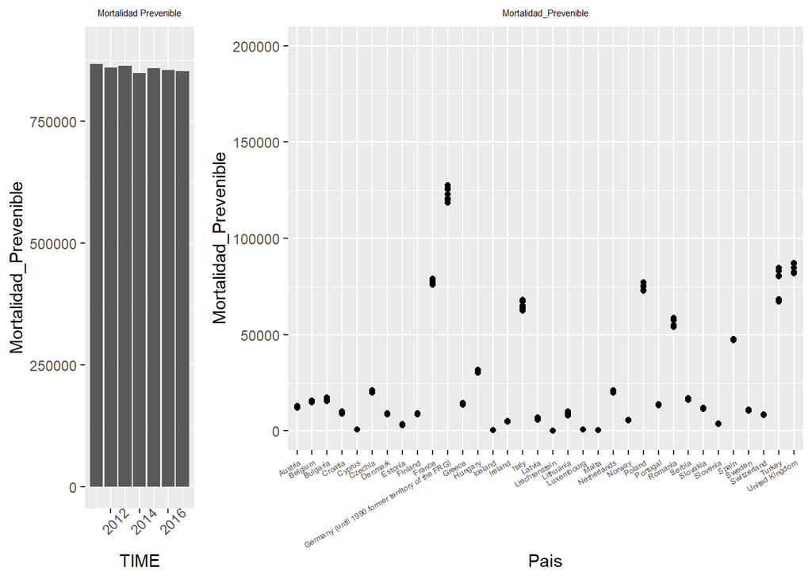

```r
#Diagrama de Puntos: CAUSAS DE MORTALIDAD
#========================================

plot7=ggplot(data=mortalidad)+geom_point(aes(x=Pais,y=Mortalidad_Prevenible))+
  theme(axis.text.x = element_text(size= 5,angle = 30,vjust=1,hjust = 1))+
  scale_y_continuous(limit=c(0,200000))+
  ggtitle("Mortalidad_Prevenible")+
  theme (plot.title = element_text(size=rel(0.5),hjust = 0.5))

plot8=ggplot(data=mortalidad)+geom_point(aes(x=Pais,y=Mortalidad_Tratable))+
  theme(axis.text.x = element_text(size= 5,angle = 30,vjust=1,hjust = 1))+
  scale_y_continuous(limit=c(0,100000))+
  ggtitle("Mortalidad_Tratable")+
  theme (plot.title = element_text(size=rel(0.5),hjust = 0.5))

plot9=ggplot(data=mortalidad)+geom_point(aes(x=Pais,y=Mortalidad_A00_B99))+
  theme(axis.text.x = element_text(size= 5,angle = 30,vjust=1,hjust = 1))+
  scale_y_continuous(limit=c(0,100000))+
  ggtitle("Mortalidad_A00_B99")+
  theme (plot.title = element_text(size=rel(0.5),hjust = 0.5))

plot10=ggplot(data=mortalidad)+geom_point(aes(x=Pais,y=Mortalidad_G00_R50))+
  theme(axis.text.x = element_text(size= 5,angle = 30,vjust=1,hjust = 1))+
  scale_y_continuous(limit=c(0,100000))+
  ggtitle("Mortalidad_G00_R50")+
  theme (plot.title = element_text(size=rel(0.5),hjust = 0.5))

plot11=ggplot(data=mortalidad)+geom_point(aes(x=Pais,y=Mortalidad_pneumonia))+
  theme(axis.text.x = element_text(size= 5,angle = 30,vjust=1,hjust = 1))+
  scale_y_continuous(limit=c(0,100000))+
  ggtitle("Mortalidad_pneumonia")+
  theme (plot.title = element_text(size=rel(0.5),hjust = 0.5))

plot12=ggplot(data=mortalidad)+geom_point(aes(x=Pais,y=Other_sepsis))+
  theme(axis.text.x = element_text(size= 5,angle = 30,vjust=1,hjust = 1))+
  scale_y_continuous(limit=c(0,100000))+
  ggtitle("Other_sepsis")+
  theme (plot.title = element_text(size=rel(0.5),hjust = 0.5))

grid.arrange(plot1,plot7,widths=c(1,3), ncol=2)
```

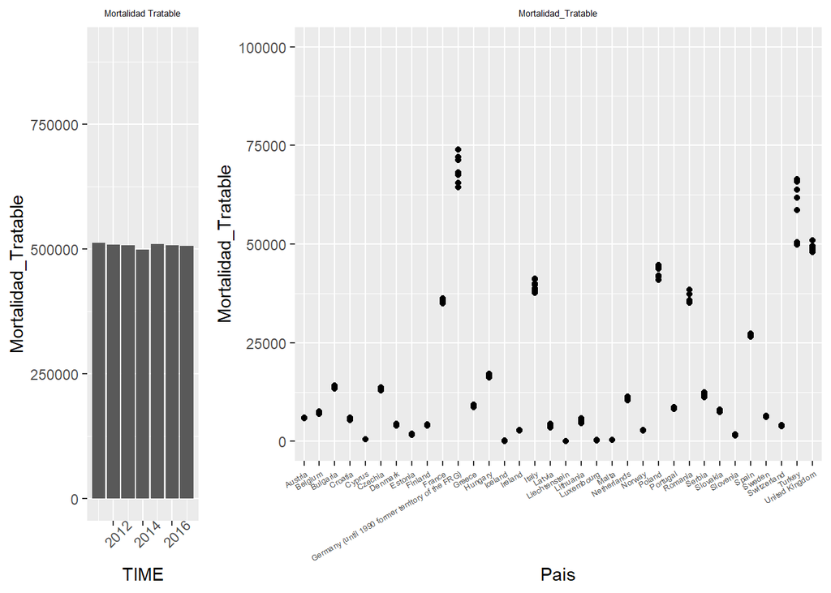

```r
grid.arrange(plot2,plot8,widths=c(1,3), ncol=2)
```

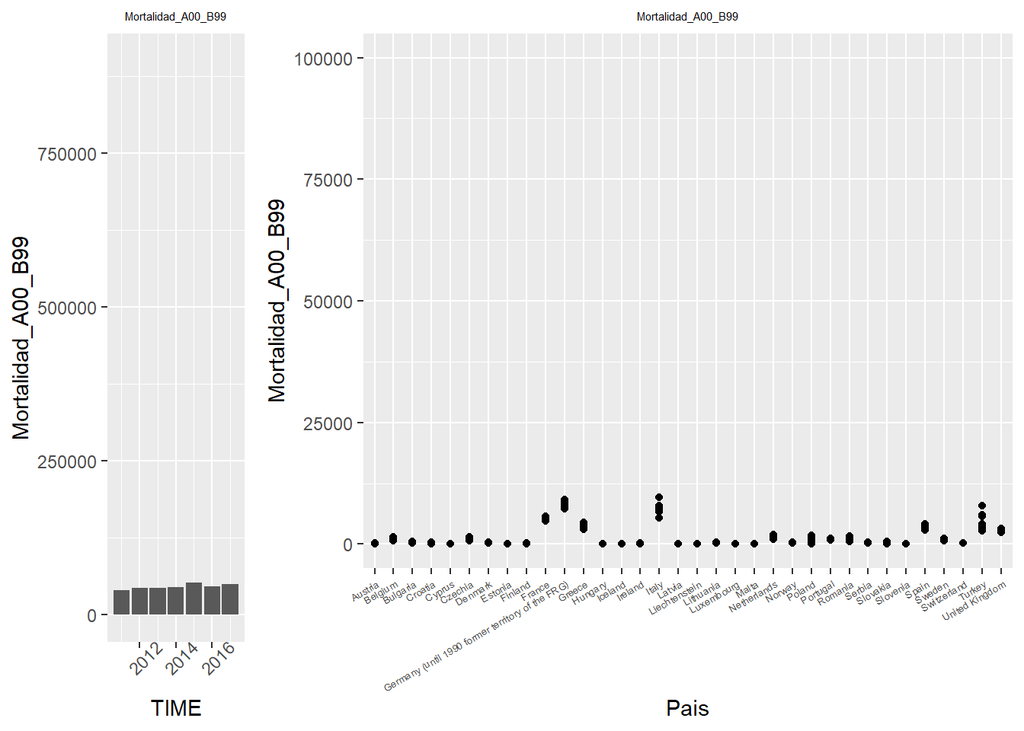

```r
grid.arrange(plot3,plot9,widths=c(1,3), ncol=2)
```

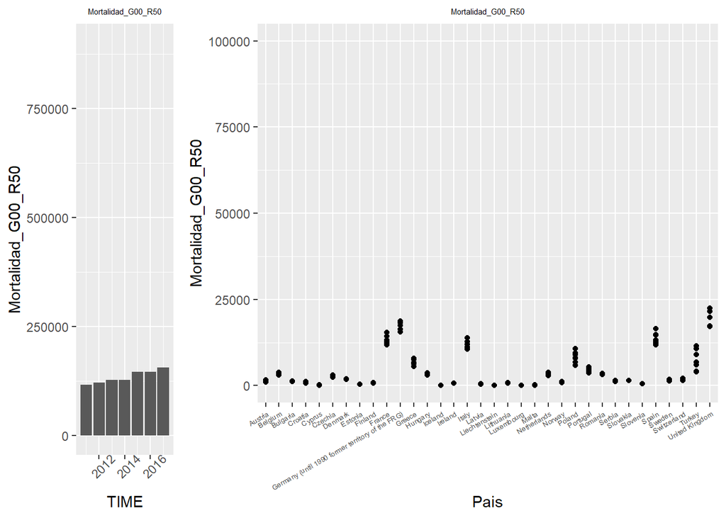

```r
grid.arrange(plot4,plot10,widths=c(1,3), ncol=2)
```

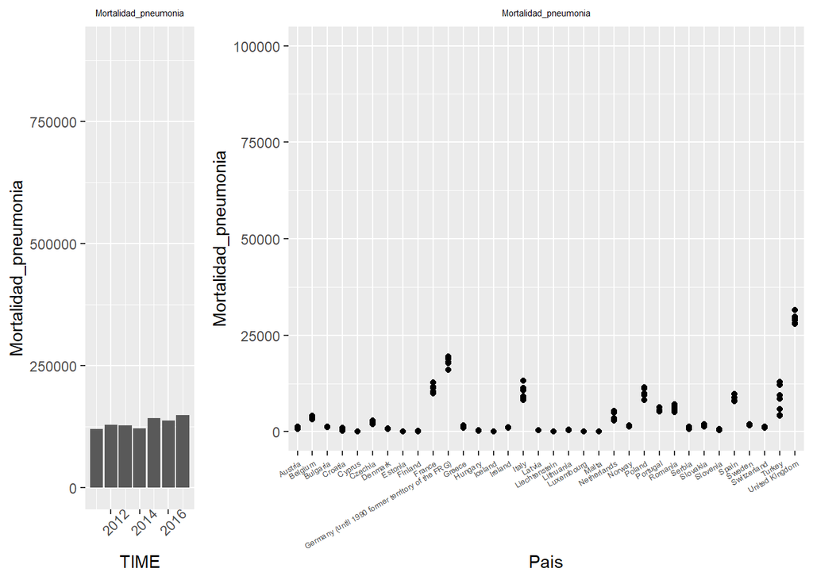

```r
grid.arrange(plot5,plot11,widths=c(1,3), ncol=2)
```

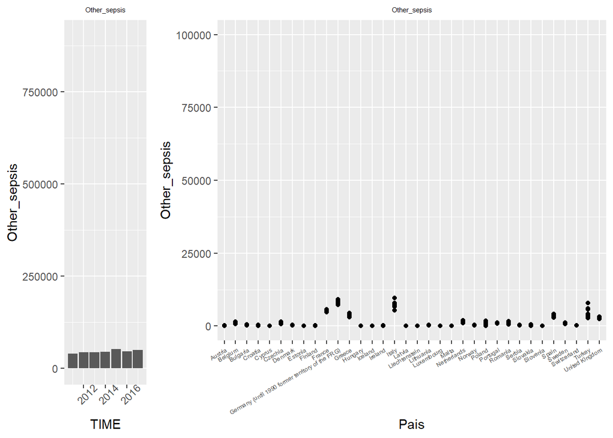

```r
grid.arrange(plot6,plot12,widths=c(1,3), ncol=2)
```

Se obtienen los 5 países con mayor índice de mortalidad según el tipo de causa que la provoca.

```r
#Se filtra por año

y_2011<-filter(mortalidad, TIME==2011)
y_2012<-filter(mortalidad, TIME==2012)
y_2013<-filter(mortalidad, TIME==2013)
y_2014<-filter(mortalidad, TIME==2014)
y_2015<-filter(mortalidad, TIME==2015)
y_2016<-filter(mortalidad, TIME==2016)
y_2017<-filter(mortalidad, TIME==2017)
```

- **Mortalidad_Prevenible**

```r
#Filtramos por Mortalidad Prevenible
mortalidad_2011<-y_2011[with(y_2011, order(-y_2011$Mortalidad_Prevenible)),]
mortalidad_2012<-y_2012[with(y_2012, order(-y_2012$Mortalidad_Prevenible )),]
mortalidad_2013<-y_2013[with(y_2013, order(-y_2013$Mortalidad_Prevenible )),]
mortalidad_2014<-y_2014[with(y_2014, order(-y_2014$Mortalidad_Prevenible )),]
mortalidad_2015<-y_2015[with(y_2015, order(-y_2015$Mortalidad_Prevenible )),]
mortalidad_2016<-y_2016[with(y_2016, order(-y_2016$Mortalidad_Prevenible )),]
mortalidad_2017<-y_2017[with(y_2017, order(-y_2017$Mortalidad_Prevenible)),]

#Se crea una tabla con la información de la variable Mortalidad_Prevenible por años

kable(mortalidad_2011[0:5,c(2,3)],
      col.names = c("País","Mortalidad_Prevenible"),
      caption = "Países con mayor Mortalidad_Prevenible en 2011")
```

Países con mayor Mortalidad_Prevenible en 2011

|  | País | Mortalidad_Prevenible |
| --- | --- | --- |
| 5 | Germany (until 1990 former territory of the FRG) | 127461.0 |
| 32 | United Kingdom | 82226.0 |
| 10 | France | 78950.5 |
| 21 | Poland | 77175.5 |
| 34 | Turkey | 68225.0 |

```r
kable(mortalidad_2012[0:5,c(2,3)],
      col.names = c("País","Mortalidad_Prevenible"),
      caption = "Países con mayor Mortalidad_Prevenible en 2012")
```

Países con mayor Mortalidad_Prevenible en 2012

|  | País | Mortalidad_Prevenible |
| --- | --- | --- |
| 5 | Germany (until 1990 former territory of the FRG) | 125457.5 |
| 32 | United Kingdom | 81962.5 |
| 10 | France | 77596.5 |
| 21 | Poland | 76992.0 |
| 34 | Turkey | 67271.5 |

```r
kable(mortalidad_2013[0:5,c(2,3)],
      col.names = c("País","Mortalidad_Prevenible"),
      caption = "Países con mayor Mortalidad_Prevenible en 2013")
```

Países con mayor Mortalidad_Prevenible en 2013

|  | País | Mortalidad_Prevenible |
| --- | --- | --- |
| 5 | Germany (until 1990 former territory of the FRG) | 126132.0 |
| 32 | United Kingdom | 82478.5 |
| 34 | Turkey | 80578.0 |
| 10 | France | 77270.0 |
| 21 | Poland | 75400.0 |

```r
kable(mortalidad_2014[0:5,c(2,3)],
      col.names = c("País","Mortalidad_Prevenible"),
      caption = "Países con mayor Mortalidad_Prevenible en 2014")
```

Países con mayor Mortalidad_Prevenible en 2014

|  | País | Mortalidad_Prevenible |
| --- | --- | --- |
| 5 | Germany (until 1990 former territory of the FRG) | 120737.5 |
| 32 | United Kingdom | 82551.0 |
| 34 | Turkey | 80566.0 |
| 10 | France | 76003.5 |
| 21 | Poland | 72755.5 |

```r
kable(mortalidad_2015[0:5,c(2,3)],
      col.names = c("País","Mortalidad_Prevenible"),
      caption = "Países con mayor Mortalidad_Prevenible en 2015")
```

Países con mayor Mortalidad_Prevenible en 2015

|  | País | Mortalidad_Prevenible |
| --- | --- | --- |
| 5 | Germany (until 1990 former territory of the FRG) | 122759.0 |
| 32 | United Kingdom | 84677.5 |
| 34 | Turkey | 80325.0 |
| 10 | France | 77864.0 |
| 21 | Poland | 72929.5 |

```r
kable(mortalidad_2016[0:5,c(2,3)],
      col.names = c("País","Mortalidad_Prevenible"),
      caption = "Países con mayor Mortalidad_Prevenible en 2016")
```

Países con mayor Mortalidad_Prevenible en 2016

|  | País | Mortalidad_Prevenible |
| --- | --- | --- |
| 5 | Germany (until 1990 former territory of the FRG) | 120129.5 |
| 32 | United Kingdom | 86777.5 |
| 34 | Turkey | 84518.5 |
| 10 | France | 77585.5 |
| 21 | Poland | 73164.5 |

```r
kable(mortalidad_2017[0:5,c(2,3)],
      col.names = c("País","Mortalidad_Prevenible"),
      caption = "Países con mayor Mortalidad_Prevenible en 2017")
```

Países con mayor Mortalidad_Prevenible en 2017

|  | País | Mortalidad_Prevenible |
| --- | --- | --- |
| 5 | Germany (until 1990 former territory of the FRG) | 118506.5 |
| 32 | United Kingdom | 87159.0 |
| 34 | Turkey | 83229.0 |
| 10 | France | 77585.5 |
| 21 | Poland | 74998.0 |

A continuación, se aprupa toda la Mortalidad_Prevenible por paises y se crea una tabla con toda la información:

```r
a1<-group_by(mortalidad,Pais)#Se agrupa por paises
a2<-select(a1,Pais:Mortalidad_Prevenible)#Seleccionamos las variables GEO y Mortalidad_Prevenible
a3<-(summarize(a2,suma=sum(Mortalidad_Prevenible/10)))#Se muestra la información por cada país, con Value=suma de los valores de cada país en los 10 años.
a4<-data.frame(a3)#Se convierte la información en un dataframe
a5<-a4[with(a4,order(-a4$suma)),]#Se ordena el DataFrame por la variable Suma de forma descendente.

#Se crea una tabla con toda la informacion
kable(a5[0:5,c(1,2)], col.names = c("País","Mortalidad_Prevenible"), caption = "Países con mayor Mortalidad_Prevenible en 2011-2017")
```

Países con mayor Mortalidad_Prevenible en 2011-2017

|  | País | Mortalidad_Prevenible |
| --- | --- | --- |
| 11 | Germany (until 1990 former territory of the FRG) | 86118.30 |
| 34 | United Kingdom | 58783.20 |
| 33 | Turkey | 54471.30 |
| 10 | France | 54285.55 |
| 24 | Poland | 52341.50 |

- **Mortalidad_Tratable**

```r
#Filtramos por Mortalidad Tratable
mortalidad_2011<-y_2011[with(y_2011, order(-y_2011$Mortalidad_Tratable)),]
mortalidad_2012<-y_2012[with(y_2012, order(-y_2012$Mortalidad_Tratable )),]
mortalidad_2013<-y_2013[with(y_2013, order(-y_2013$Mortalidad_Tratable )),]
mortalidad_2014<-y_2014[with(y_2014, order(-y_2014$Mortalidad_Tratable )),]
mortalidad_2015<-y_2015[with(y_2015, order(-y_2015$Mortalidad_Tratable )),]
mortalidad_2016<-y_2016[with(y_2016, order(-y_2016$Mortalidad_Tratable )),]
mortalidad_2017<-y_2017[with(y_2017, order(-y_2017$Mortalidad_Tratable)),]

#Se crea una tabla con la información de la variable Mortalidad_Tratable por años

kable(mortalidad_2011[0:5,c(2,4)],
      col.names = c("País","Mortalidad_Tratable"),
      caption = "Países con mayor Mortalidad_Tratable en 2011")
```

Países con mayor Mortalidad_Tratable en 2011

|  | País | Mortalidad_Tratable |
| --- | --- | --- |
| 5 | Germany (until 1990 former territory of the FRG) | 74029.0 |
| 34 | Turkey | 50411.0 |
| 32 | United Kingdom | 48861.0 |
| 21 | Poland | 44643.5 |
| 12 | Italy | 41124.5 |

```r
kable(mortalidad_2012[0:5,c(2,4)],
      col.names = c("País","Mortalidad_Tratable"),
      caption = "Países con mayor Mortalidad_Tratable en 2012")
```

Países con mayor Mortalidad_Tratable en 2012

|  | País | Mortalidad_Tratable |
| --- | --- | --- |
| 5 | Germany (until 1990 former territory of the FRG) | 72005.5 |
| 34 | Turkey | 49912.5 |
| 32 | United Kingdom | 48594.5 |
| 21 | Poland | 44342.0 |
| 12 | Italy | 41222.0 |

```r
kable(mortalidad_2013[0:5,c(2,4)],
      col.names = c("País","Mortalidad_Tratable"),
      caption = "Países con mayor Mortalidad_Tratable en 2013")
```

Países con mayor Mortalidad_Tratable en 2013

|  | País | Mortalidad_Tratable |
| --- | --- | --- |
| 5 | Germany (until 1990 former territory of the FRG) | 71225.0 |
| 34 | Turkey | 58609.0 |
| 32 | United Kingdom | 48137.5 |
| 21 | Poland | 43734.0 |
| 12 | Italy | 39717.0 |

```r
kable(mortalidad_2014[0:5,c(2,4)],
      col.names = c("País","Mortalidad_Tratable"),
      caption = "Países con mayor Mortalidad_Tratable en 2014")
```

Países con mayor Mortalidad_Tratable en 2014

|  | País | Mortalidad_Tratable |
| --- | --- | --- |
| 5 | Germany (until 1990 former territory of the FRG) | 67489.5 |
| 34 | Turkey | 61678.0 |
| 32 | United Kingdom | 48027.0 |
| 21 | Poland | 40861.5 |
| 12 | Italy | 38732.0 |

```r
kable(mortalidad_2015[0:5,c(2,4)],
      col.names = c("País","Mortalidad_Tratable"),
      caption = "Países con mayor Mortalidad_Tratable en 2015")
```

Países con mayor Mortalidad_Tratable en 2015

|  | País | Mortalidad_Tratable |
| --- | --- | --- |
| 5 | Germany (until 1990 former territory of the FRG) | 68212.0 |
| 34 | Turkey | 63826.0 |
| 32 | United Kingdom | 49579.5 |
| 21 | Poland | 41704.5 |
| 12 | Italy | 40000.0 |

```r
kable(mortalidad_2016[0:5,c(2,4)],
      col.names = c("País","Mortalidad_Tratable"),
      caption = "Países con mayor Mortalidad_Tratable en 2016")
```

Países con mayor Mortalidad_Tratable en 2016

|  | País | Mortalidad_Tratable |
| --- | --- | --- |
| 34 | Turkey | 66395.5 |
| 5 | Germany (until 1990 former territory of the FRG) | 65536.5 |
| 32 | United Kingdom | 50951.5 |
| 21 | Poland | 42060.5 |
| 12 | Italy | 37638.0 |

```r
kable(mortalidad_2017[0:5,c(2,4)],
      col.names = c("País","Mortalidad_Tratable"),
      caption = "Países con mayor Mortalidad_Tratable en 2017")
```

Países con mayor Mortalidad_Tratable en 2017

|  | País | Mortalidad_Tratable |
| --- | --- | --- |
| 34 | Turkey | 65810.0 |
| 5 | Germany (until 1990 former territory of the FRG) | 64417.5 |
| 32 | United Kingdom | 50880.0 |
| 21 | Poland | 43948.0 |
| 12 | Italy | 38040.5 |

A continuación, se aprupa toda la Mortalidad_Tratable por paises y se crea una tabla con toda la información:

```r
a1<-group_by(mortalidad,Pais)#Se agrupa por paises
#Seleccionamos las variables GEO y Mortalidad_Tratable
a2<-select(a1,Pais:Mortalidad_Tratable)
#Se muestra la información por cada país,
#con Value=suma de los valores de cada país en los 10 años.
a3<-(summarize(a2,suma=sum(Mortalidad_Tratable/10)))
a4<-data.frame(a3)#Se convierte la información en un dataframe
a5<-a4[with(a4,order(-a4$suma)),]#Se ordena el DataFrame
#por la variable Suma de forma descendente.

#Se crea una tabla con toda la informacion
kable(a5[0:5,c(1,2)], col.names = c("País","Mortalidad_Tratable"),
      caption = "Países con mayor Mortalidad_Tratable en 2011-2017")
```

Países con mayor Mortalidad_Tratable en 2011-2017

|  | País | Mortalidad_Tratable |
| --- | --- | --- |
| 11 | Germany (until 1990 former territory of the FRG) | 48291.5 |
| 33 | Turkey | 41664.2 |
| 34 | United Kingdom | 34503.1 |
| 24 | Poland | 30129.4 |
| 16 | Italy | 27647.4 |

- **Mortalidad_A00_B99**

```r
#Filtramos por Mortalidad_A00_B99
mortalidad_2011<-y_2011[with(y_2011, order(-y_2011$Mortalidad_A00_B99)),]
mortalidad_2012<-y_2012[with(y_2012, order(-y_2012$Mortalidad_A00_B99 )),]
mortalidad_2013<-y_2013[with(y_2013, order(-y_2013$Mortalidad_A00_B99 )),]
mortalidad_2014<-y_2014[with(y_2014, order(-y_2014$Mortalidad_A00_B99 )),]
mortalidad_2015<-y_2015[with(y_2015, order(-y_2015$Mortalidad_A00_B99 )),]
mortalidad_2016<-y_2016[with(y_2016, order(-y_2016$Mortalidad_A00_B99 )),]
mortalidad_2017<-y_2017[with(y_2017, order(-y_2017$Mortalidad_A00_B99)),]

#Se crea una tabla con la información de la variable Mortalidad_A00_B99 por años

kable(mortalidad_2011[0:5,c(2,5)],
      col.names = c("País","Mortalidad_A00_B99"),
      caption = "Países con mayor Mortalidad_A00_B99 en 2011")
```

|  | País | Mortalidad_A00_B99 |
| --- | --- | --- |
| 5 | Germany (until 1990 former territory of the FRG) | 7411 |
| 12 | Italy | 5423 |
| 10 | France | 5094 |
| 8 | Greece | 3626 |
| 9 | Spain | 2946 |

```r
kable(mortalidad_2012[0:5,c(2,5)],
      col.names = c("País","Mortalidad_A00_B99"),
      caption = "Países con mayor Mortalidad_A00_B99 en 2012")
```

Países con mayor Mortalidad_A00_B99 en 2012

|  | País | Mortalidad_A00_B99 |
| --- | --- | --- |
| 5 | Germany (until 1990 former territory of the FRG) | 8232 |
| 12 | Italy | 6630 |
| 10 | France | 5330 |
| 8 | Greece | 4440 |
| 34 | Turkey | 3343 |

```r
kable(mortalidad_2013[0:5,c(2,5)],
      col.names = c("País","Mortalidad_A00_B99"),
      caption = "Países con mayor Mortalidad_A00_B99 en 2013")
```

Países con mayor Mortalidad_A00_B99 en 2013

|  | País | Mortalidad_A00_B99 |
| --- | --- | --- |
| 5 | Germany (until 1990 former territory of the FRG) | 7901 |
| 12 | Italy | 7163 |
| 10 | France | 5277 |
| 8 | Greece | 4079 |
| 34 | Turkey | 3527 |

```r
kable(mortalidad_2014[0:5,c(2,5)],
      col.names = c("País","Mortalidad_A00_B99"),
      caption = "Países con mayor Mortalidad_A00_B99 en 2014")
```

Países con mayor Mortalidad_A00_B99 en 2014

|  | País | Mortalidad_A00_B99 |
| --- | --- | --- |
| 5 | Germany (until 1990 former territory of the FRG) | 8444 |
| 12 | Italy | 7573 |
| 10 | France | 5333 |
| 34 | Turkey | 4053 |
| 9 | Spain | 3224 |

```r
kable(mortalidad_2015[0:5,c(2,5)],
      col.names = c("País","Mortalidad_A00_B99"),
      caption = "Países con mayor Mortalidad_A00_B99 en 2015")
```

Países con mayor Mortalidad_A00_B99 en 2015

|  | País | Mortalidad_A00_B99 |
| --- | --- | --- |
| 12 | Italy | 9656 |
| 5 | Germany (until 1990 former territory of the FRG) | 9189 |
| 10 | France | 5726 |
| 34 | Turkey | 5678 |
| 9 | Spain | 4148 |

```r
kable(mortalidad_2016[0:5,c(2,5)],
      col.names = c("País","Mortalidad_A00_B99"),
      caption = "Países con mayor Mortalidad_A00_B99 en 2016")
```

Países con mayor Mortalidad_A00_B99 en 2016

|  | País | Mortalidad_A00_B99 |
| --- | --- | --- |
| 5 | Germany (until 1990 former territory of the FRG) | 7329 |
| 12 | Italy | 6594 |
| 34 | Turkey | 6056 |
| 10 | France | 4793 |
| 9 | Spain | 3856 |

```r
kable(mortalidad_2017[0:5,c(2,5)],
      col.names = c("País","Mortalidad_A00_B99"),
      caption = "Países con mayor Mortalidad_A00_B99 en 2017")
```

Países con mayor Mortalidad_A00_B99 en 2017

|  | País | Mortalidad_A00_B99 |
| --- | --- | --- |
| 12 | Italy | 7875 |
| 34 | Turkey | 7873 |
| 5 | Germany (until 1990 former territory of the FRG) | 7364 |
| 10 | France | 5333 |
| 9 | Spain | 3754 |

A continuación, se aprupa toda la Mortalidad_A00_B99 por paises y se crea una tabla con toda la información:

```r
a1<-group_by(mortalidad,Pais)#Se agrupa por paises
#Seleccionamos las variables GEO y Mortalidad_A00_B99
a2<-select(a1,Pais:Mortalidad_A00_B99)
#Se muestra la información por cada país,
#con Value=suma de los valores de cada país en los 10 años.
a3<-(summarize(a2,suma=sum(Mortalidad_A00_B99/10)))
a4<-data.frame(a3)#Se convierte la información en un dataframe
a5<-a4[with(a4,order(-a4$suma)),]#Se ordena el DataFrame
#por la variable Suma de forma descendente.

#Se crea una tabla con toda la informacion
kable(a5[0:5,c(1,2)], col.names = c("País","Mortalidad_A00_B99"),
      caption = "Países con mayor Mortalidad_A00_B99 en 2011-2017")
```

Países con mayor Mortalidad_A00_B99 en 2011-2017

|  | País | Mortalidad_A00_B99 |
| --- | --- | --- |
| 11 | Germany (until 1990 former territory of the FRG) | 5587.0 |
| 16 | Italy | 5091.4 |
| 10 | France | 3688.6 |
| 33 | Turkey | 3319.8 |
| 12 | Greece | 2622.7 |

- **Mortalidad_G00_R50**

```r
#Filtramos por Mortalidad_A00_B99
mortalidad_2011<-y_2011[with(y_2011, order(-y_2011$Mortalidad_G00_R50)),]
mortalidad_2012<-y_2012[with(y_2012, order(-y_2012$Mortalidad_G00_R50 )),]
mortalidad_2013<-y_2013[with(y_2013, order(-y_2013$Mortalidad_G00_R50 )),]
mortalidad_2014<-y_2014[with(y_2014, order(-y_2014$Mortalidad_G00_R50 )),]
mortalidad_2015<-y_2015[with(y_2015, order(-y_2015$Mortalidad_G00_R50 )),]
mortalidad_2016<-y_2016[with(y_2016, order(-y_2016$Mortalidad_G00_R50 )),]
mortalidad_2017<-y_2017[with(y_2017, order(-y_2017$Mortalidad_G00_R50)),]

#Se crea una tabla con la información de la variable Mortalidad_G00_R50 por años

kable(mortalidad_2011[0:5,c(2,6)],
      col.names = c("País","Mortalidad_G00_R50"),
      caption = "Países con mayor Mortalidad_G00_R50 en 2011")
```

Países con mayor Mortalidad_G00_R50 en 2011

|  | País | Mortalidad_G00_R50 |
| --- | --- | --- |
| 32 | United Kingdom | 17160 |
| 5 | Germany (until 1990 former territory of the FRG) | 15593 |
| 10 | France | 11842 |
| 9 | Spain | 11834 |
| 12 | Italy | 10691 |

```r
kable(mortalidad_2012[0:5,c(2,6)],
      col.names = c("País","Mortalidad_G00_R50"),
      caption = "Países con mayor Mortalidad_G00_R50 en 2012")
```

Países con mayor Mortalidad_G00_R50 en 2012

|  | País | Mortalidad_G00_R50 |
| --- | --- | --- |
| 32 | United Kingdom | 17092 |
| 5 | Germany (until 1990 former territory of the FRG) | 15598 |
| 10 | France | 13153 |
| 9 | Spain | 12611 |
| 12 | Italy | 11116 |

```r
kable(mortalidad_2013[0:5,c(2,6)],
      col.names = c("País","Mortalidad_G00_R50"),
      caption = "Países con mayor Mortalidad_G00_R50 en 2013")
```

Países con mayor Mortalidad_G00_R50 en 2013

|  | País | Mortalidad_G00_R50 |
| --- | --- | --- |
| 5 | Germany (until 1990 former territory of the FRG) | 17419 |
| 32 | United Kingdom | 17322 |
| 10 | France | 13122 |
| 9 | Spain | 12386 |
| 12 | Italy | 10771 |

```r
kable(mortalidad_2014[0:5,c(2,6)],
      col.names = c("País","Mortalidad_G00_R50"),
      caption = "Países con mayor Mortalidad_G00_R50 en 2014")
```

Países con mayor Mortalidad_G00_R50 en 2014

|  | País | Mortalidad_G00_R50 |
| --- | --- | --- |
| 32 | United Kingdom | 19823 |
| 5 | Germany (until 1990 former territory of the FRG) | 16342 |
| 9 | Spain | 13197 |
| 10 | France | 12390 |
| 12 | Italy | 10547 |

```r
kable(mortalidad_2015[0:5,c(2,6)],
      col.names = c("País","Mortalidad_G00_R50"),
      caption = "Países con mayor Mortalidad_G00_R50 en 2015")
```

Países con mayor Mortalidad_G00_R50 en 2015

|  | País | Mortalidad_G00_R50 |
| --- | --- | --- |
| 32 | United Kingdom | 21479 |
| 5 | Germany (until 1990 former territory of the FRG) | 18180 |
| 10 | France | 15375 |
| 9 | Spain | 14612 |
| 12 | Italy | 12710 |

```r
kable(mortalidad_2016[0:5,c(2,6)],
      col.names = c("País","Mortalidad_G00_R50"),
      caption = "Países con mayor Mortalidad_G00_R50 en 2016")
```

Países con mayor Mortalidad_G00_R50 en 2016

|  | País | Mortalidad_G00_R50 |
| --- | --- | --- |
| 32 | United Kingdom | 21470 |
| 5 | Germany (until 1990 former territory of the FRG) | 17371 |
| 9 | Spain | 14704 |
| 10 | France | 14303 |
| 12 | Italy | 11993 |

```r
kable(mortalidad_2017[0:5,c(2,6)],
      col.names = c("País","Mortalidad_G00_R50"),
      caption = "Países con mayor Mortalidad_G00_R50 en 2017")
```

Países con mayor Mortalidad_G00_R50 en 2017

|  | País | Mortalidad_G00_R50 |
| --- | --- | --- |
| 32 | United Kingdom | 22501 |
| 5 | Germany (until 1990 former territory of the FRG) | 18690 |
| 9 | Spain | 16445 |
| 10 | France | 14303 |
| 12 | Italy | 13815 |

A continuación, se aprupa toda la Mortalidad_G00_R50 por paises y se crea una tabla con toda la información:

```r
a1<-group_by(mortalidad,Pais)#Se agrupa por paises
#Seleccionamos las variables GEO y Mortalidad_G00_R50
a2<-select(a1,Pais:Mortalidad_G00_R50)
#Se muestra la información por cada país,
#con Value=suma de los valores de cada país en los 10 años.
a3<-(summarize(a2,suma=sum(Mortalidad_G00_R50/10)))
a4<-data.frame(a3)#Se convierte la información en un dataframe
a5<-a4[with(a4,order(-a4$suma)),]#Se ordena el DataFrame
#por la variable Suma de forma descendente.

#Se crea una tabla con toda la informacion
kable(a5[0:5,c(1,2)], col.names = c("País","Mortalidad_G00_R50"),
      caption = "Países con mayor Mortalidad_G00_R50 en 2011-2017")
```

Países con mayor Mortalidad_G00_R50 en 2011-2017

|  | País | Mortalidad_G00_R50 |
| --- | --- | --- |
| 34 | United Kingdom | 13684.7 |
| 11 | Germany (until 1990 former territory of the FRG) | 11919.3 |
| 30 | Spain | 9578.9 |
| 10 | France | 9448.8 |
| 16 | Italy | 8164.3 |

- **Mortalidad_pneumonia**

```r
#Filtramos por Mortalidad_pneumonia
mortalidad_2011<-y_2011[with(y_2011, order(-y_2011$Mortalidad_pneumonia)),]
mortalidad_2012<-y_2012[with(y_2012, order(-y_2012$Mortalidad_pneumonia )),]
mortalidad_2013<-y_2013[with(y_2013, order(-y_2013$Mortalidad_pneumonia )),]
mortalidad_2014<-y_2014[with(y_2014, order(-y_2014$Mortalidad_pneumonia )),]
mortalidad_2015<-y_2015[with(y_2015, order(-y_2015$Mortalidad_pneumonia )),]
mortalidad_2016<-y_2016[with(y_2016, order(-y_2016$Mortalidad_pneumonia )),]
mortalidad_2017<-y_2017[with(y_2017, order(-y_2017$Mortalidad_pneumonia)),]

#Se crea una tabla con la información de la variable Mortalidad_pneumonia por años

kable(mortalidad_2011[0:5,c(2,7)],
      col.names = c("País","Mortalidad_pneumonia"),
      caption = "Países con mayor Mortalidad_pneumonia en 2011")
```

Países con mayor Mortalidad_pneumonia en 2011

|  | País | Mortalidad_pneumonia |
| --- | --- | --- |
| 32 | United Kingdom | 27968 |
| 5 | Germany (until 1990 former territory of the FRG) | 18020 |
| 10 | France | 9971 |
| 21 | Poland | 8262 |
| 12 | Italy | 8211 |

```r
kable(mortalidad_2012[0:5,c(2,7)],
      col.names = c("País","Mortalidad_pneumonia"),
      caption = "Países con mayor Mortalidad_pneumonia en 2012")
```

Países con mayor Mortalidad_pneumonia en 2012

|  | País | Mortalidad_pneumonia |
| --- | --- | --- |
| 32 | United Kingdom | 28945 |
| 5 | Germany (until 1990 former territory of the FRG) | 17776 |
| 10 | France | 11600 |
| 21 | Poland | 9395 |
| 12 | Italy | 9088 |

```r
kable(mortalidad_2013[0:5,c(2,7)],
      col.names = c("País","Mortalidad_pneumonia"),
      caption = "Países con mayor Mortalidad_pneumonia en 2013")
```

Países con mayor Mortalidad_pneumonia en 2013

|  | País | Mortalidad_pneumonia |
| --- | --- | --- |
| 32 | United Kingdom | 28936 |
| 5 | Germany (until 1990 former territory of the FRG) | 18820 |
| 10 | France | 11388 |
| 21 | Poland | 11212 |
| 12 | Italy | 8852 |

```r
kable(mortalidad_2014[0:5,c(2,7)],
      col.names = c("País","Mortalidad_pneumonia"),
      caption = "Países con mayor Mortalidad_pneumonia en 2014")
```

Países con mayor Mortalidad_pneumonia en 2014

|  | País | Mortalidad_pneumonia |
| --- | --- | --- |
| 32 | United Kingdom | 28011 |
| 5 | Germany (until 1990 former territory of the FRG) | 16019 |
| 10 | France | 10444 |
| 21 | Poland | 9925 |
| 12 | Italy | 8935 |

```r
kable(mortalidad_2015[0:5,c(2,7)],
      col.names = c("País","Mortalidad_pneumonia"),
      caption = "Países con mayor Mortalidad_pneumonia en 2015")
```

Países con mayor Mortalidad_pneumonia en 2015

|  | País | Mortalidad_pneumonia |
| --- | --- | --- |
| 32 | United Kingdom | 31593 |
| 5 | Germany (until 1990 former territory of the FRG) | 19403 |
| 10 | France | 12692 |
| 12 | Italy | 11312 |
| 21 | Poland | 11223 |

```r
kable(mortalidad_2016[0:5,c(2,7)],
      col.names = c("País","Mortalidad_pneumonia"),
      caption = "Países con mayor Mortalidad_pneumonia en 2016")
```

Países con mayor Mortalidad_pneumonia en 2016

|  | País | Mortalidad_pneumonia |
| --- | --- | --- |
| 32 | United Kingdom | 29746 |
| 5 | Germany (until 1990 former territory of the FRG) | 18044 |
| 10 | France | 12723 |
| 34 | Turkey | 12053 |
| 12 | Italy | 10683 |

```r
kable(mortalidad_2017[0:5,c(2,7)],
      col.names = c("País","Mortalidad_pneumonia"),
      caption = "Países con mayor Mortalidad_pneumonia en 2017")
```

Países con mayor Mortalidad_pneumonia en 2017

|  | País | Mortalidad_pneumonia |
| --- | --- | --- |
| 32 | United Kingdom | 29517 |
| 5 | Germany (until 1990 former territory of the FRG) | 19143 |
| 12 | Italy | 13242 |
| 34 | Turkey | 12864 |
| 10 | France | 12692 |

A continuación, se aprupa toda la Mortalidad_pneumonia por paises y se crea una tabla con toda la información:

```r
a1<-group_by(mortalidad,Pais)#Se agrupa por paises
#Seleccionamos las variables GEO y Mortalidad_pneumonia
a2<-select(a1,Pais:Mortalidad_pneumonia)
#Se muestra la información por cada país,
#con Value=suma de los valores de cada país en los 10 años.
a3<-(summarize(a2,suma=sum(Mortalidad_pneumonia/10)))
a4<-data.frame(a3)#Se convierte la información en un dataframe
a5<-a4[with(a4,order(-a4$suma)),]#Se ordena el DataFrame
#por la variable Suma de forma descendente.

#Se crea una tabla con toda la informacion
kable(a5[0:5,c(1,2)], col.names = c("País","Mortalidad_pneumonia"),
      caption = "Países con mayor Mortalidad_pneumonia en 2011-2017")
```

Países con mayor Mortalidad_pneumonia en 2011-2017

|  | País | Mortalidad_pneumonia |
| --- | --- | --- |
| 34 | United Kingdom | 20471.6 |
| 11 | Germany (until 1990 former territory of the FRG) | 12722.5 |
| 10 | France | 8151.0 |
| 24 | Poland | 7105.6 |
| 16 | Italy | 7032.3 |

- **Other_sepsis**

```r
#Filtramos por Other_sepsis
mortalidad_2011<-y_2011[with(y_2011, order(-y_2011$Other_sepsis)),]
mortalidad_2012<-y_2012[with(y_2012, order(-y_2012$Other_sepsis)),]
mortalidad_2013<-y_2013[with(y_2013, order(-y_2013$Other_sepsis)),]
mortalidad_2014<-y_2014[with(y_2014, order(-y_2014$Other_sepsis)),]
mortalidad_2015<-y_2015[with(y_2015, order(-y_2015$Other_sepsis)),]
mortalidad_2016<-y_2016[with(y_2016, order(-y_2016$Other_sepsis)),]
mortalidad_2017<-y_2017[with(y_2017, order(-y_2017$Other_sepsis)),]

#Se crea una tabla con la información de la variable Other_sepsis por años

kable(mortalidad_2011[0:5,c(2,8)],
      col.names = c("País","Other_sepsis"),
      caption = "Países con mayor Other_sepsis en 2011")
```

Países con mayor Other_sepsis en 2011

|  | País | Other_sepsis |
| --- | --- | --- |
| 5 | Germany (until 1990 former territory of the FRG) | 7411 |
| 12 | Italy | 5423 |
| 10 | France | 5094 |
| 8 | Greece | 3626 |
| 9 | Spain | 2946 |

```r
kable(mortalidad_2012[0:5,c(2,8)],
      col.names = c("País","Other_sepsis"),
      caption = "Países con mayor Other_sepsis en 2012")
```

Países con mayor Other_sepsis en 2012

|  | País | Other_sepsis |
| --- | --- | --- |
| 5 | Germany (until 1990 former territory of the FRG) | 8232 |
| 12 | Italy | 6630 |
| 10 | France | 5330 |
| 8 | Greece | 4440 |
| 34 | Turkey | 3343 |

```r
kable(mortalidad_2013[0:5,c(2,8)],
      col.names = c("País","Other_sepsis"),
      caption = "Países con mayor Other_sepsis en 2013")
```

Países con mayor Other_sepsis en 2013

|  | País | Other_sepsis |
| --- | --- | --- |
| 5 | Germany (until 1990 former territory of the FRG) | 7901 |
| 12 | Italy | 7163 |
| 10 | France | 5277 |
| 8 | Greece | 4079 |
| 34 | Turkey | 3527 |

```r
kable(mortalidad_2014[0:5,c(2,8)],
      col.names = c("País","Other_sepsis"),
      caption = "Países con mayor Other_sepsis en 2014")
```

Países con mayor Other_sepsis en 2014

|  | País | Other_sepsis |
| --- | --- | --- |
| 5 | Germany (until 1990 former territory of the FRG) | 8444 |
| 12 | Italy | 7573 |
| 10 | France | 5333 |
| 34 | Turkey | 4053 |
| 9 | Spain | 3224 |

```r
kable(mortalidad_2015[0:5,c(2,8)],
      col.names = c("País","Other_sepsis"),
      caption = "Países con mayor Other_sepsis en 2015")
```

Países con mayor Other_sepsis en 2015

|  | País | Other_sepsis |
| --- | --- | --- |
| 12 | Italy | 9656 |
| 5 | Germany (until 1990 former territory of the FRG) | 9189 |
| 10 | France | 5726 |
| 34 | Turkey | 5678 |
| 9 | Spain | 4148 |

```r
kable(mortalidad_2016[0:5,c(2,8)],
      col.names = c("País","Other_sepsis"),
      caption = "Países con mayor Other_sepsis en 2016")
```

Países con mayor Other_sepsis en 2016

|  | País | Other_sepsis |
| --- | --- | --- |
| 5 | Germany (until 1990 former territory of the FRG) | 7329 |
| 12 | Italy | 6594 |
| 34 | Turkey | 6056 |
| 10 | France | 4793 |
| 9 | Spain | 3856 |

```r
kable(mortalidad_2017[0:5,c(2,8)],
      col.names = c("País","Other_sepsis"),
      caption = "Países con mayor Other_sepsis en 2017")
```

Países con mayor Other_sepsis en 2017

|  | País | Other_sepsis |
| --- | --- | --- |
| 12 | Italy | 7875 |
| 34 | Turkey | 7873 |
| 5 | Germany (until 1990 former territory of the FRG) | 7364 |
| 10 | France | 5333 |
| 9 | Spain | 3754 |

A continuación, se aprupa toda la Other_sepsis por paises y se crea una tabla con toda la información:

```r
a1<-group_by(mortalidad,Pais)#Se agrupa por paises
#Seleccionamos las variables GEO y Other_sepsis
a2<-select(a1,Pais:Other_sepsis)
#Se muestra la información por cada país,
#con Value=suma de los valores de cada país en los 10 años.
a3<-(summarize(a2,suma=sum(Other_sepsis/10)))
a4<-data.frame(a3)#Se convierte la información en un dataframe
a5<-a4[with(a4,order(-a4$suma)),]#Se ordena el DataFrame
#por la variable Suma de forma descendente.

#Se crea una tabla con toda la informacion
kable(a5[0:5,c(1,2)], col.names = c("País","Other_sepsis"),
      caption = "Países con mayor Other_sepsis en 2011-2017")
```

Países con mayor Other_sepsis en 2011-2017

|  | País | Other_sepsis |
| --- | --- | --- |
| 11 | Germany (until 1990 former territory of the FRG) | 5587.0 |
| 16 | Italy | 5091.4 |
| 10 | France | 3688.6 |
| 33 | Turkey | 3319.8 |
| 12 | Greece | 2622.7 |

- **1.1.3 Normalidad de la variable “Value” (Mortalidad)**

Se comprueba con métodos visuales si la variable tiene una distribución normal.

**Mortalidad_Prevenible**

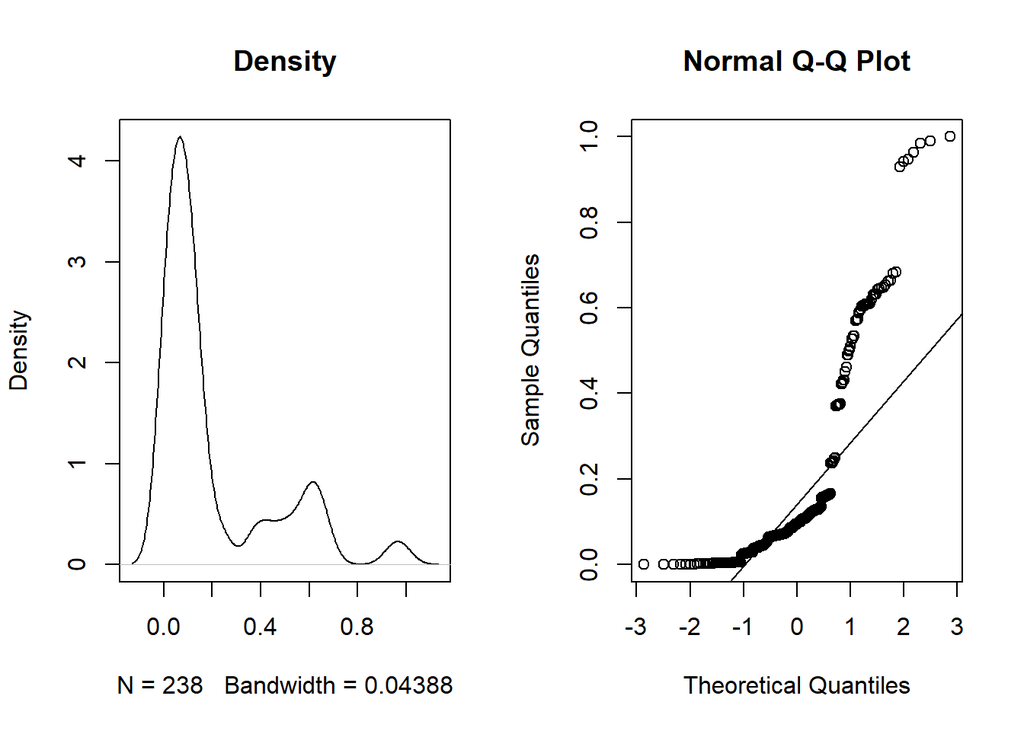

```r
par(mfrow=c(1,2))
plot(density(mortalidad$Mortalidad_Prevenible_norm) ,main="Density")
qqnorm(mortalidad$Mortalidad_Prevenible_norm)
qqline(mortalidad$Mortalidad_Prevenible_norm)
```

Para estudiar si una muestra proviene de una población con distribución normal, se disponen de tres herramientas:

- Histograma o Densidad
- Gráficos cuantil cuantil (QQplot)
- Pruebas de hipótesis.

Si en la prueba de Densidad se observa sesgo hacia uno de los lados de la gráfica, sería indicio de que la muestra no proviene de una población normal.Si por otra parte, sí se observa simetría, **NO** se garantiza que la muestra provenga de una población normal. En estos casos sería necesario utilizar otras herramientas como **QQplot y pruebas de hipótesis**.

En la gráfica Densidad de la variable “Mortalidad_Prevenible_norm”, se observa claramente sesgo hacia la derecha, por lo que no se considera normalidad. Se puede confirmar observando la gráfica QQplot en la que la línea que grafica qqline sirve de referencia para interpretar el gráfico. Si se tuviese una muestra distribuída normalmente, se esperaría que los puntos del gráfico quantil quantil estuviesen perfectamente alineados con la línea de referencia, y observamos que para este caso, “Mortalidad_Prevenible_norm” no se alinea.

Por otro lado, se realizan las pruebas de hipótesis:

- $h_0: La muestra proviene de una población normal.
- $h_1: La muestra NO proviene de una población normal.

Se aplica la prueba Shapiro-Wilk:

```r
shapiro.test(mortalidad$Mortalidad_Prevenible_norm)
```

```
##
##  Shapiro-Wilk normality test
##
## data:  mortalidad$Mortalidad_Prevenible_norm
## W = 0.74781, p-value < 2.2e-16
```

Se observa un p-value muy pequeño, mucho más pequeño que cualquier nivel de significación ($alpha$=0.5) por lo que se rechaza la hipótesis nula y asumimos **No normalidad** en la muestra.

**Mortalidad_Tratable**

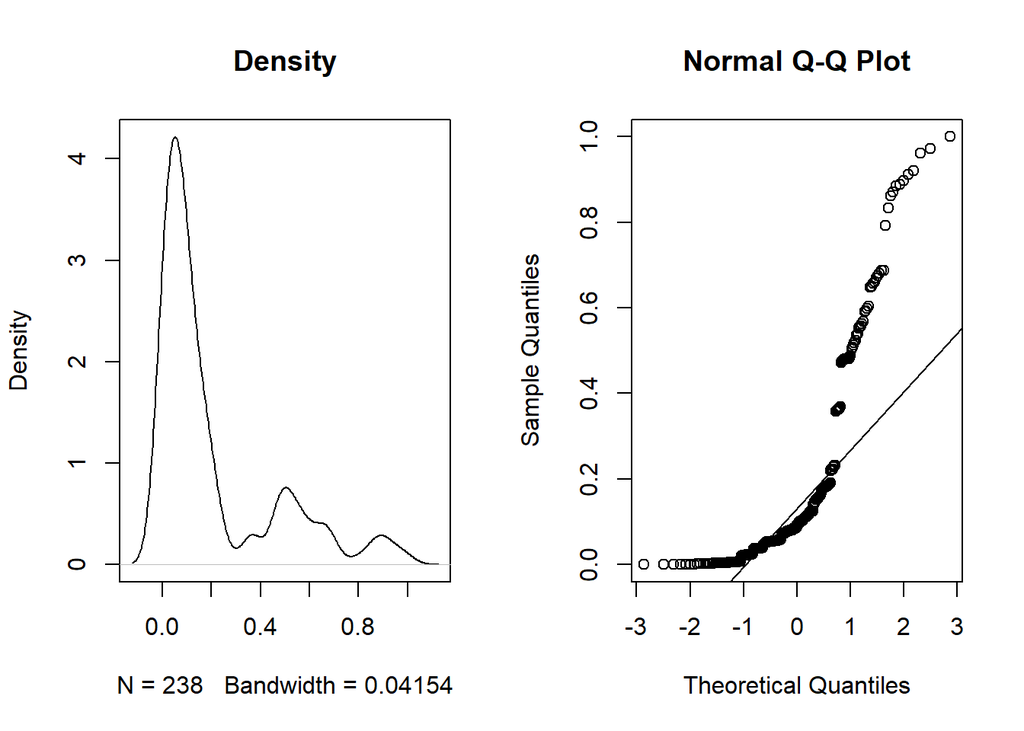

```r
par(mfrow=c(1,2))
plot(density(mortalidad$Mortalidad_Tratable_norm) ,main="Density")
qqnorm(mortalidad$Mortalidad_Tratable_norm)
qqline(mortalidad$Mortalidad_Tratable_norm)
```

Tras aplicar la prueba Shapiro-Wilk:

```r
shapiro.test(mortalidad$Mortalidad_Tratable_norm)
```

```
##
##  Shapiro-Wilk normality test
##
## data:  mortalidad$Mortalidad_Tratable_norm
## W = 0.75393, p-value < 2.2e-16
```

Se observa un p-value muy pequeño, mucho más pequeño que cualquier nivel de significación ($alpha$=0.5) por lo que se rechaza la hipótesis nula y asumimos **No normalidad** en la muestra.

**Mortalidad_A00_B99**

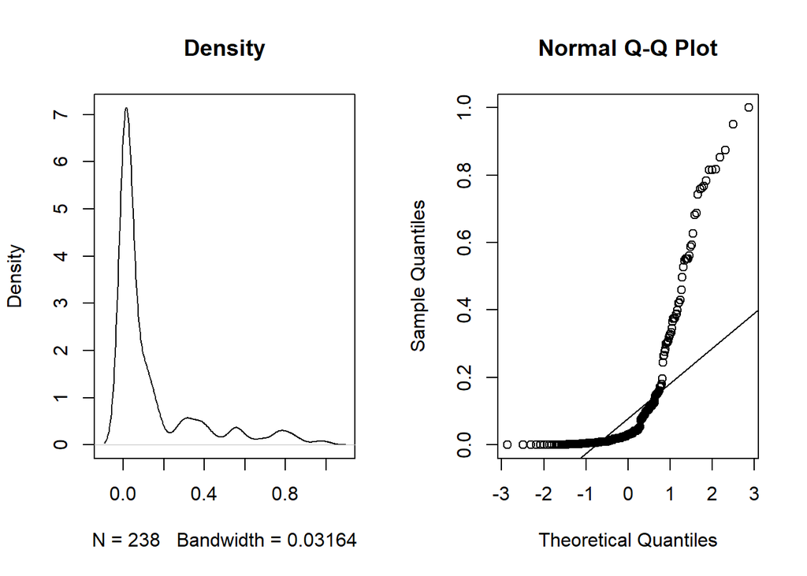

```r
par(mfrow=c(1,2))
plot(density(mortalidad$Mortalidad_A00_B99_norm) ,main="Density")
qqnorm(mortalidad$Mortalidad_A00_B99_norm)
qqline(mortalidad$Mortalidad_A00_B99_norm)
```

En la gráfica Densidad de la variable “Mortalidad_A00_B99” , se observa claramente una figura que no se aproxima a la curva de normalidad. Se puede confirmar observando la gráfica QQplot en la que la línea que grafica qqline sirve de referencia para interpretar el gráfico, no se alinea con los puntos de los valores de la variable “Mortalidad_A00_B99”.

Tras aplicar la prueba Shapiro-Wilk:

```r
shapiro.test(mortalidad$Mortalidad_A00_B99_norm)
```

```
##
##  Shapiro-Wilk normality test
##
## data:  mortalidad$Mortalidad_A00_B99_norm
## W = 0.66004, p-value < 2.2e-16
```

Se observa un p-value muy pequeño, mucho más pequeño que cualquier nivel de significación ($alpha$=0.5) por lo que se rechaza la hipótesis nula y asumimos **No normalidad** en la muestra.

**Mortalidad_G00_R50**

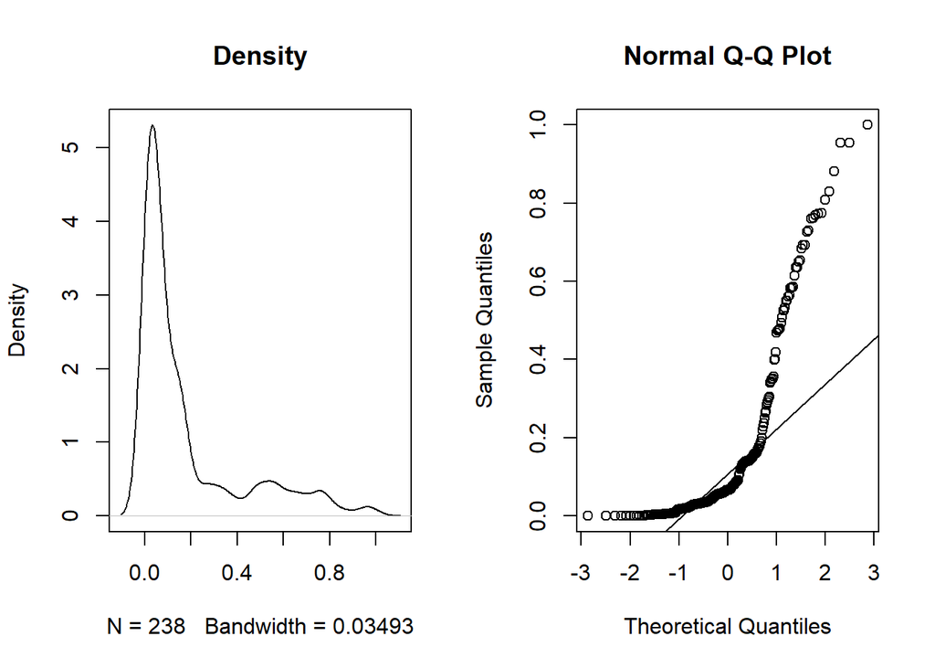

```r
par(mfrow=c(1,2))
plot(density(mortalidad$Mortalidad_G00_R50_norm) ,main="Density")
qqnorm(mortalidad$Mortalidad_G00_R50_norm)
qqline(mortalidad$Mortalidad_G00_R50_norm)
```

En la gráfica Densidad de la variable “Mortalidad_G00_R50” , se observa claramente una figura que no se aproxima a la curva de normalidad. Se puede confirmar observando la gráfica QQplot en la que la línea que grafica qqline sirve de referencia para interpretar el gráfico, no se alinea con los puntos de los valores de la variable “Mortalidad_G00_R50”.

Tras aplicar la prueba Shapiro-Wilk:

```r
shapiro.test(mortalidad$Mortalidad_G00_R50_norm)
```

```
##
##  Shapiro-Wilk normality test
##
## data:  mortalidad$Mortalidad_G00_R50_norm
## W = 0.72615, p-value < 2.2e-16
```

Se observa un p-value muy pequeño, mucho más pequeño que cualquier nivel de significación ($alpha$=0.5) por lo que se rechaza la hipótesis nula y asumimos **No normalidad** en la muestra.

**Mortalidad_pneumonia**

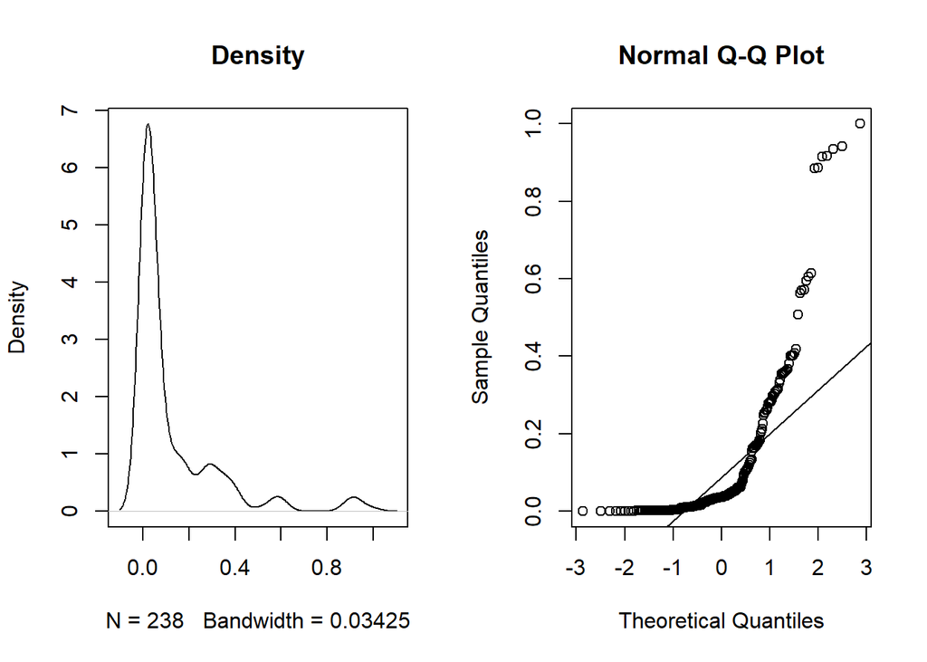

```r
par(mfrow=c(1,2))
plot(density(mortalidad$Mortalidad_pneumonia_norm) ,main="Density")
qqnorm(mortalidad$Mortalidad_pneumonia_norm)
qqline(mortalidad$Mortalidad_pneumonia_norm)
```

En la gráfica Densidad de la variable “Mortalidad_pneumonia” , se observa claramente una figura que no se aproxima a la curva de normalidad. Se puede confirmar observando la gráfica QQplot en la que la línea que grafica qqline sirve de referencia para interpretar el gráfico, no se alinea con los puntos de los valores de la variable “Mortalidad_pneumonia”.

Tras aplicar la prueba Shapiro-Wilk:

```r
shapiro.test(mortalidad$Mortalidad_pneumonia_norm)
```

```
##
##  Shapiro-Wilk normality test
##
## data:  mortalidad$Mortalidad_pneumonia_norm
## W = 0.64545, p-value < 2.2e-16
```

Se observa un p-value muy pequeño, mucho más pequeño que cualquier nivel de significación ($alpha$=0.5) por lo que se rechaza la hipótesis nula y asumimos **No normalidad** en la muestra.

**Other_sepsis**

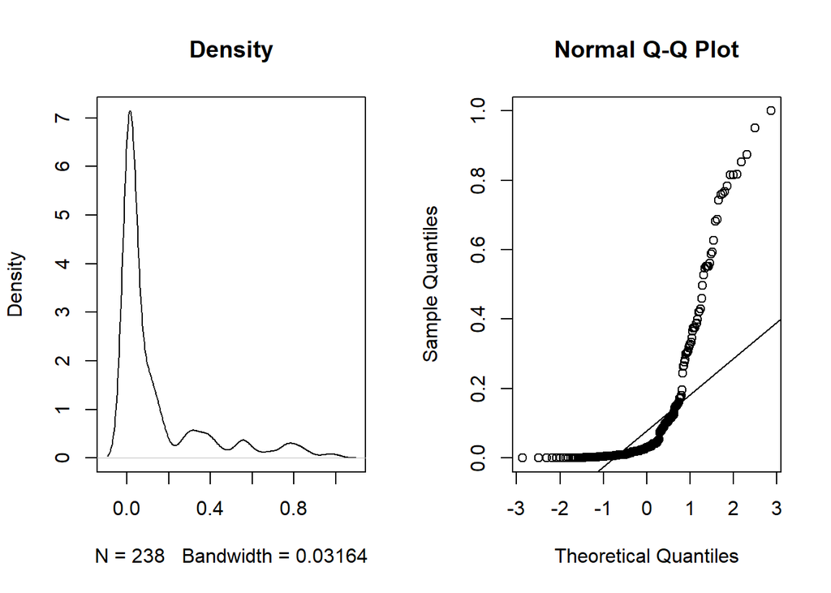

```r
par(mfrow=c(1,2))
plot(density(mortalidad$Other_sepsis_norm) ,main="Density")
qqnorm(mortalidad$Other_sepsis_norm)
qqline(mortalidad$Other_sepsis_norm)
```

En la gráfica Densidad de la variable “Other_sepsis” , se observa claramente una figura que no se aproxima a la curva de normalidad. Se puede confirmar observando la gráfica QQplot en la que la línea que grafica qqline sirve de referencia para interpretar el gráfico, no se alinea con los puntos de los valores de la variable “Other_sepsis”. Tras aplicar la prueba Shapiro-Wilk:

```r
shapiro.test(mortalidad$Other_sepsis_norm)
```

```
##
##  Shapiro-Wilk normality test
##
## data:  mortalidad$Other_sepsis_norm
## W = 0.66004, p-value < 2.2e-16
```

Se observa un p-value muy pequeño, mucho más pequeño que cualquier nivel de significación ($alpha$=0.5) por lo que se rechaza la hipótesis nula y asumimos **No normalidad** en la muestra.